# Reproducible Research 2021: Live analysis of betting odds for tennis matches

Rafał Rysiejko

Michał Sałach

May 2021

# Best bet prediction

## Introduction

In our project, we search for the most profitable bets to make on the tennis matches for a given moment. We consider seven popular Polish bookmakers whose betting odds are reported on an ongoing basis on flashscore.pl/tennis. We are interested in the results only (who wins) and only in the ongoing or scheduled matches for a given day. It may be safely assumed that each match will have a winner. It is also pretty always the case that for each match, there is a favorite of the bookmakers (the bookmakers do not have to be unanimous, or it may in principle happen that the odds for both players are the same - this does not cause a problem for our analysis). A favorite of a bookmaker in a given match is the player for whom offers are lower (closer to 1). There is also a favorite of a client of the bookmaker - this is the player whose win would grant the client a profit.

Given that in reality, offers for both players are greater than 1, a client does not have to bet all their money on a favorite to achieve some profit. The remaining amount of money the client would bet on a non-favorite as a form of insurance in the case of misfortune (favorite loses). A no-risk bet is, therefore, a bet in which there is a proportion of money to bet, such that a client of a bookmaker has a profit also when their favorite loses. For example, in betting, odds for a player A (the bookmaker’s favorite) are 1.5, and for a player, B is 3.5, a client may bet 700 PLN on a player A and 300 PLN on a player B, granting a win of 1050 PLN (5% profit) in both cases. Such bets rather do not happen in reality, but the project aims to find the offers that come the closest to this, for any moment in time.

Our analysis is looking for the best bets to make from two angles: minimizing loss and maximizing return. Hence, we use two notions of profitability: In the first sense, we are interested in bets that would give a client minimal loss, having fixed on some level expected to return in the case of the client’s favorite win. In the second sense, we are looking for bets that would give a maximal client return in their favorite’s win, having fixed on some level the loss in the adverse case. The report will therefore accept 3 meta-prameters: *money* (money to bet, defaul 1000 PLN), *expected_return* (default 0.1) and *adverse_return* (default -0.2).

### Summary statistics

|  | eFortuna | STS | Betclick | Betfan | Lvbet | Pzbuk | Totolotek |
| --- | --- | --- | --- | --- | --- | --- | --- |
| Number of bets | 153.000000 | 154.000000 | 138.000000 | 140.000000 | 138.000000 | 137.000000 | 87.000000 |
| Average offer | 2.421503 | 2.353506 | 2.404348 | 2.427143 | 2.430362 | 2.491971 | 2.223448 |

[output not shown]

### Best bet for maximising potential return

Having 1000 PLN, the best bet to do right now in order to have maximum-20% return in the case of a favorite loss and maximal return in the case of the favorite win is to bet 792.08PLN on Novak Djokovic (Srb, ATP ranking: 1) on [eFortuna](https://www.efortuna.pl/) (betting odds: 1.01, expected return: 6237.62 PLN, that is 523.76%) and 207.92 PLN on Pablo Cuevas (Uru, ATP ranking: 92) on [eFortuna](https://www.efortuna.pl/) (betting odds: 30) in ATP - Single: French Open (France), grass courts - 1/32-finału (starting at 2021-06-03 15:15:00).

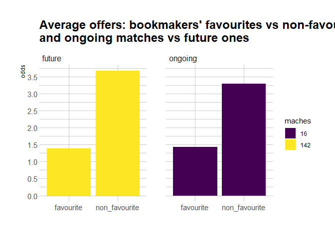

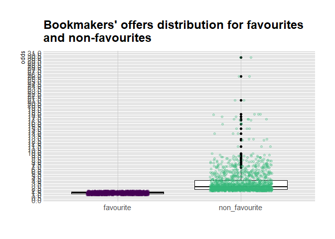

### Top 3 bets for each bookmaker

**eFortuna**

*Best return in adverse scenario given -20% return in the case of the favorite’s win*

1. Bet 117.02 PLN for Zarina Diyas and 882.98 PLN for Elise Mertens in WTA - Single: French Open (France), grass courts - 1/32-finału (starting 2021-06-03 15:15:00) with an expected return of 971.28
2. Bet 59.83 PLN for Gianluca Mager and 940.17 PLN for Jannik Sinner in ATP - Single: French Open (France), grass courts - 1/32-finału (starting 2021-06-03 15:15:00) with an expected return of 955.5
3. Bet 148.65 PLN for Philipp Kohlschreiber and 851.35 PLN for Asłan Karacjew in ATP - Single: French Open (France), grass courts - 1/32-finału (starting 2021-06-03 15:15:00) with an expected return of 953.51

*Best return in maximum return scenario given 10% expected return in the case of the favorite’s win*

1. Bet 792.08 PLN for Novak Djokovic and 207.92 PLN for Pablo Cuevas in ATP - Single: French Open (France), grass courts - 1/32-finału (starting 2021-06-03 15:15:00) with an expected return of 6237.62
2. Bet 792.08 PLN for Novak Djokovic and 207.92 PLN for Pablo Cuevasin ATP - Single: French Open (France), grass courts - 1/32-finału (starting 2021-06-03 15:15:00) with an expected return of 6237.62
3. Bet 792.08 PLN for Novak Djokovic and 207.92 PLN for Pablo Cuevas in ATP - Single: French Open (France), grass courts - 1/32-finału (starting 2021-06-03 15:15:00) with an expected return of 6237.62

**STS**

*Best return in adverse scenario given -20% return in the case of the favorite’s win*

1. Bet 148.65 PLN for Philipp Kohlschreiber and 851.35 PLN for Asłan Karacjew in ATP - Single: French Open (France), grass courts - 1/32-finału (starting 2021-06-03 15:15:00) with an expected return of 953.51
2. Bet 59.83 PLN for Jasmine Paolini and 940.17 PLN for Maria Sakkari in WTA - Single: French Open (France), grass courts - 1/32-finału (starting 2021-06-03 15:15:00) with an expected return of 948.1
3. Bet 51.72 PLN for Qiang Wang and 948.28 PLN for Cori Gauff in WTA - Single: French Open (France), grass courts - 1/32-finału (starting 2021-06-03 15:15:00) with an expected return of 947.33

*Best return in maximum return scenario given 10% expected return in the case of the favorite’s win*

1. Bet 792.08 PLN for Novak Djokovic and 207.92 PLN for Pablo Cuevas in ATP - Single: French Open (France), grass courts - 1/32-finału (starting 2021-06-03 15:15:00) with an expected return of 6237.62
2. Bet 792.08 PLN for Rafael Nadal and 207.92 PLN for Richard Gasquetin ATP - Single: French Open (France), grass courts - 1/32-finału (starting 2021-06-03 15:15:00) with an expected return of 5405.94
3. Bet 955.56 PLN for Iga Świątek and 44.44 PLN for Rebecca Peterson in WTA - Single: French Open (France), grass courts - 1/32-finału (starting 2021-06-03 15:15:00) with an expected return of 4019.42

**Betclick**

*Best return in adverse scenario given -20% return in the case of the favorite’s win*

1. Bet 305.56 PLN for Georgina Garcia-Perez / Julia Wachaczyk and 694.44 PLN for Gabriela Dabrowski / Leylah Annie Fernandez in WTA - DEBEL: French Open (France), grass courts - 1/32-finału (starting 2021-06-03 15:15:00) with an expected return of 937.5
2. Bet 183.33 PLN for Alexandr Binda and 816.67 PLN for Ivan Gakhov in ITF Mens - Single: M15 Shymkent 6 (Kazakhstan), grass courts - 1/8 final (starting 2021-06-03 15:15:00) with an expected return of 898.33
3. Bet 207.55 PLN for Victoria Hu and 792.45 PLN for Conny Perrin in ITF Womens - Single: W25 Santo Domingo (Dominicanna), hard courts - 1/8 final (starting 2021-06-03 15:15:00) with an expected return of 887.55

*Best return in maximum return scenario given 10% expected return in the case of the favorite’s win*

1. Bet 792.08 PLN for Novak Djokovic and 207.92 PLN for Pablo Cuevas in ATP - Single: French Open (France), grass courts - 1/32-finału (starting 2021-06-03 15:15:00) with an expected return of 6237.62
2. Bet 792.08 PLN for Rafael Nadal and 207.92 PLN for Richard Gasquetin ATP - Single: French Open (France), grass courts - 1/32-finału (starting 2021-06-03 15:15:00) with an expected return of 5405.94
3. Bet 784.31 PLN for Oleksandr Ovcharenko and 215.69 PLN for Timur Mukhtarulin in ITF Mens - Single: M15 Novomoskovsk 3 (Ukraine), grass courts - 1/16-finału (starting 2021-06-03 15:15:00) with an expected return of 2098.63

**Betfan**

*Best return in adverse scenario given -20% return in the case of the favorite’s win*

1. Bet 371.62 PLN for Lloyd George Harris and 628.38 PLN for Cameron Norrie in ATP - Single: French Open (France), grass courts - 1/32-finału (starting 2021-06-03 15:15:00) with an expected return of 942.57
2. Bet 120 PLN for Marton Fucsovics / Stefano Travaglia and 880 PLN for Marcus Daniell / Philipp Oswald in ATP - DEBEL: French Open (France), grass courts - 1/32-finału (starting 2021-06-03 15:15:00) with an expected return of 941.01
3. Bet 120 PLN for Marton Fucsovics / Stefano Travaglia and 880 PLN for Marcus Daniell / Philipp Oswald in ATP - DEBEL: French Open (France), grass courts - 1/32-finału (starting 2021-06-03 15:15:00) with an expected return of 941.01

*Best return in maximum return scenario given 10% expected return in the case of the favorite’s win*

1. Bet 792.08 PLN for Novak Djokovic and 207.92 PLN for Pablo Cuevas in ATP - Single: French Open (France), grass courts - 1/32-finału (starting 2021-06-03 15:15:00) with an expected return of 6237.62
2. Bet 792.08 PLN for Rafael Nadal and 207.92 PLN for Richard Gasquetin ATP - Single: French Open (France), grass courts - 1/32-finału (starting 2021-06-03 15:15:00) with an expected return of 5405.94
3. Bet 784.31 PLN for Oleksandr Ovcharenko and 215.69 PLN for Timur Mukhtarulin in ITF Mens - Single: M15 Novomoskovsk 3 (Ukraine), grass courts - 1/16-finału (starting 2021-06-03 15:15:00) with an expected return of 2098.63

**Pzbuk**

*Best return in adverse scenario given -20% return in the case of the favorite’s win*

1. Bet 183.33 PLN for Gianluca Mager and 816.67 PLN for Jannik Sinner in ATP - Single: French Open (France), grass courts - 1/32-finału (starting 2021-06-03 15:15:00) with an expected return of 955.5
2. Bet 51.72 PLN for Dan Added / Jo-Wilfried Tsonga and 948.28 PLN for Juan-Sebastian Cabal / Robert Farah in ATP - DEBEL: French Open (France), grass courts - 1/16-finału (starting 2021-06-03 15:15:00) with an expected return of 947.33
3. Bet 266.67 PLN for Yoshihito Nishioka and 733.33 PLN for Lorenzo Musetti in ATP - Single: French Open (France), grass courts - 1/32-finału (starting 2021-06-03 15:15:00) with an expected return of 942.57

*Best return in maximum return scenario given 10% expected return in the case of the favorite’s win*

1. Bet 761.9 PLN for Jeremy Beale / Thomas John Fancutt and 238.1 PLN for Esteban Bruna / Nicolas Bruna in ITF Mens - DEBEL: M15 Monastir 22 (Tunisia), hard courts - quarter finals (starting 2021-06-03 15:15:00) with an expected return of 1964.29
2. Bet 761.9 PLN for Jeremy Beale / Thomas John Fancutt and 238.1 PLN for Esteban Bruna / Nicolas Brunain ITF Mens - DEBEL: M15 Monastir 22 (Tunisia), hard courts - quarter finals (starting 2021-06-03 15:15:00) with an expected return of 1964.29
3. Bet 761.9 PLN for Jeremy Beale / Thomas John Fancutt and 238.1 PLN for Esteban Bruna / Nicolas Bruna in ITF Mens - DEBEL: M15 Monastir 22 (Tunisia), hard courts - quarter finals (starting 2021-06-03 15:15:00) with an expected return of 1964.29

**Lvbet**

*Best return in adverse scenario given -20% return in the case of the favorite’s win*

1. Bet 183.33 PLN for Dan Added / Jo-Wilfried Tsonga and 816.67 PLN for Juan-Sebastian Cabal / Robert Farah in ATP - DEBEL: French Open (France), grass courts - 1/16-finału (starting 2021-06-03 15:15:00) with an expected return of 947.33
2. Bet 247.19 PLN for Marton Fucsovics / Stefano Travaglia and 752.81 PLN for Marcus Daniell / Philipp Oswald in ATP - DEBEL: French Open (France), grass courts - 1/32-finału (starting 2021-06-03 15:15:00) with an expected return of 941.01
3. Bet 244.44 PLN for Tomislav Brkic / Nikola Cacic and 755.56 PLN for Marcel Granollers-Pujol / Horacio Zeballos in ATP - DEBEL: French Open (France), grass courts - 1/16-finału (starting 2021-06-03 15:15:00) with an expected return of 929.33

*Best return in maximum return scenario given 10% expected return in the case of the favorite’s win*

1. Bet 747.66 PLN for Evgeniya Burdina / Mariam Dalakishvili and 252.34 PLN for Angelina Graovac / Ksenia Meshcheryakova in ITF Womens - DEBEL: W15 Shymkent 6 (Kazakhstan), grass courts - quarter finals (starting 2021-06-03 15:15:00) with an expected return of 2043.93
2. Bet 747.66 PLN for Evgeniya Burdina / Mariam Dalakishvili and 252.34 PLN for Angelina Graovac / Ksenia Meshcheryakovain ITF Womens - DEBEL: W15 Shymkent 6 (Kazakhstan), grass courts - quarter finals (starting 2021-06-03 15:15:00) with an expected return of 2043.93
3. Bet 747.66 PLN for Evgeniya Burdina / Mariam Dalakishvili and 252.34 PLN for Angelina Graovac / Ksenia Meshcheryakova in ITF Womens - DEBEL: W15 Shymkent 6 (Kazakhstan), grass courts - quarter finals (starting 2021-06-03 15:15:00) with an expected return of 2043.93

**Totolotek**

*Best return in adverse scenario given -20% return in the case of the favorite’s win*

1. Bet 117.02 PLN for Zarina Diyas and 882.98 PLN for Elise Mertens in WTA - Single: French Open (France), grass courts - 1/32-finału (starting 2021-06-03 15:15:00) with an expected return of 971.28
2. Bet 185.19 PLN for Georgina Garcia-Perez / Julia Wachaczyk and 814.81 PLN for Gabriela Dabrowski / Leylah Annie Fernandez in WTA - DEBEL: French Open (France), grass courts - 1/32-finału (starting 2021-06-03 15:15:00) with an expected return of 937.5
3. Bet 379.31 PLN for Facundo Bagnis and 620.69 PLN for Jan-Lennard Struff in ATP - Single: French Open (France), grass courts - 1/32-finału (starting 2021-06-03 15:15:00) with an expected return of 918.62

*Best return in maximum return scenario given 10% expected return in the case of the favorite’s win*

1. Bet 792.08 PLN for Novak Djokovic and 207.92 PLN for Pablo Cuevas in ATP - Single: French Open (France), grass courts - 1/32-finału (starting 2021-06-03 15:15:00) with an expected return of 6237.62
2. Bet 792.08 PLN for Rafael Nadal and 207.92 PLN for Richard Gasquetin ATP - Single: French Open (France), grass courts - 1/32-finału (starting 2021-06-03 15:15:00) with an expected return of 5405.94
3. Bet 914.89 PLN for Elise Mertens and 85.11 PLN for Zarina Diyas in WTA - Single: French Open (France), grass courts - 1/32-finału (starting 2021-06-03 15:15:00) with an expected return of 2563.64

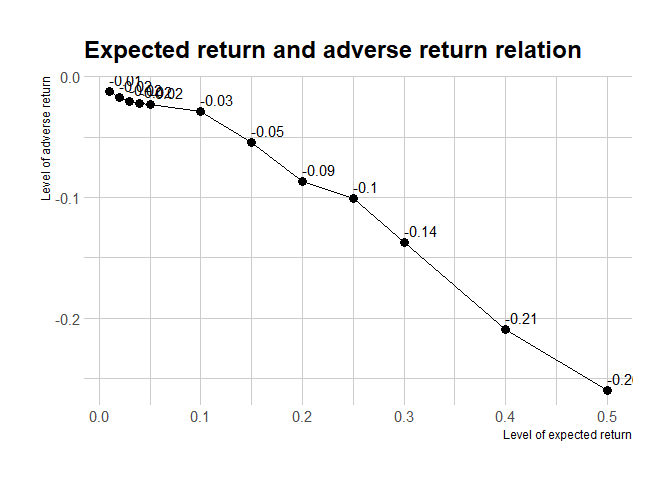

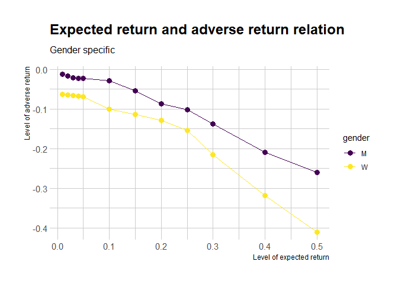

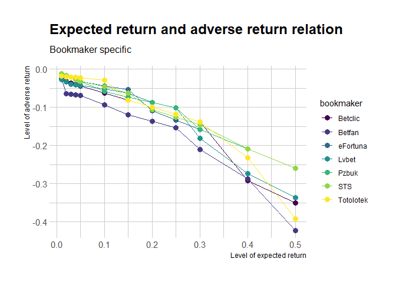

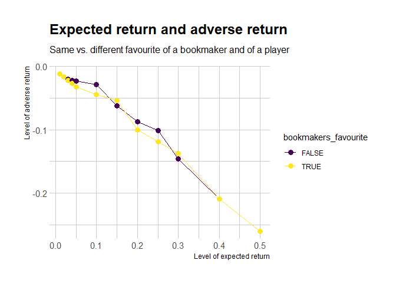

**Disclaimer**

*Please note, that online betting is a gambling entertainment vehicle, and that it carries with it a certain degree of financial risk. Players should be aware of this risk, and govern themselves accordingly.*